# Babylab scores vs neuro scores

M. Rolland

17/09/2021

# 1 Intro

Here we present correlations between the sepages neuro scores and the babylab eye tracking scores **limited to experiments performed at 24 months only** (N = 150).

List of measured scores:

- **CBCL**: Child Behavior Check List at **2 years**
- **MCHAT**: Modified Checklist for Autism in Toddlers score at **2 years**
- **SRS**: Social Responsiveness Scale at **3 years**
- **BRIEFP**: Behavior Rating Inventory of Executive Function – Preschool Version at **3 years**

# 2 Correlation between babylab scores

- fixation duration: mean fixation duration for the scene exploration and face recognition tasks
- reaction time: reaction time at the pursuit task, “time before disengaging central target”
- reaction to novelty: reaction to novelty at the face task: [New-Old]/[New+Old], Positive ratio means attention to novel faces while negative ratio indicate attention to previously seen faces (preference for familiar faces).
- percent eyes: percent time spent looking at eyes
- mean map: similarity/dissimilarity of gaze location at the scene exploration task. higher = more similar to others
- looking time: total looking time at the scene and face tasks, sum of effective fixation time (ie sum of all fixation times, without saccades)

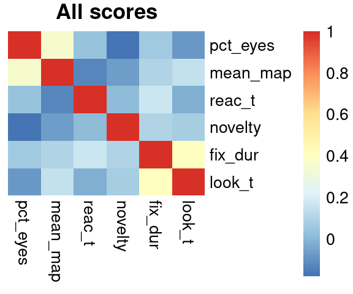

Correlations between babylab scores

|  | fix_dur | reac_t | pct_eyes | mean_map | novelty | look_t |
| --- | --- | --- | --- | --- | --- | --- |
| fix_dur | 1.00 | 0.17 | 0.07 | 0.09 | 0.10 | 0.40 |
| reac_t | 0.17 | 1.00 | 0.04 | -0.13 | 0.02 | -0.02 |
| pct_eyes | 0.07 | 0.04 | 1.00 | 0.36 | -0.18 | -0.08 |
| mean_map | 0.09 | -0.13 | 0.36 | 1.00 | -0.06 | 0.15 |
| novelty | 0.10 | 0.02 | -0.18 | -0.06 | 1.00 | 0.07 |
| look_t | 0.40 | -0.02 | -0.08 | 0.15 | 0.07 | 1.00 |

- except for mean map and % eyes (r = 0.36) and fixation duration and looking time (r = 0.40) all scores are rather independent (abs(r) < 0.2)
- maybe worth noting
  - r = 0.17 (reaction time and fixation duration)
  - r = -0.18 (%eyes and reaction to novelty)

# 3 Correlation between all neuro scores

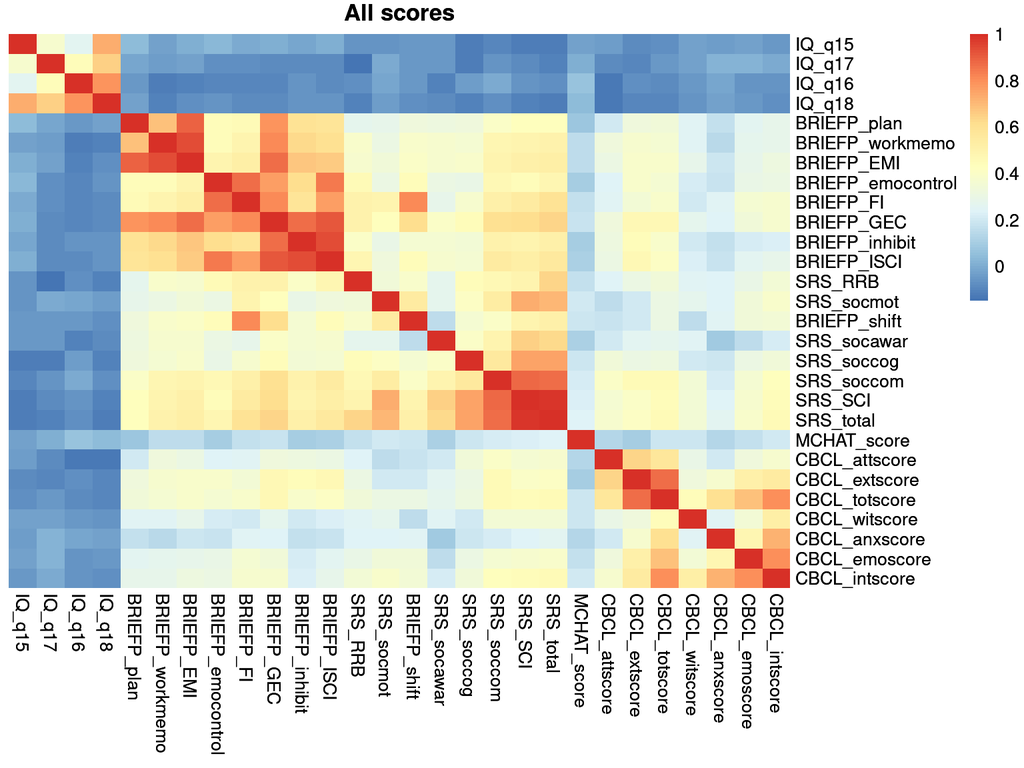

- Scores are clustered/correlated by type (SRS scores correlated with each other, etc)
- SRS and BRIEFP scores more specifically correlated
- MCHAT and IQ not correlated to others, IQ seems independent from the others
- For Claire:
  - **How are IQ and non IQ scores used in the assessment of child neurodev?**

# 4 PCA analysis

MCHAT score excluded from this analysis due to too many missing (only complete cases allowed for PCA).

PCA computed on neuro scores, babylab scores added on top, **DID NOT CONTRIBUTE TO COMPUTATION**

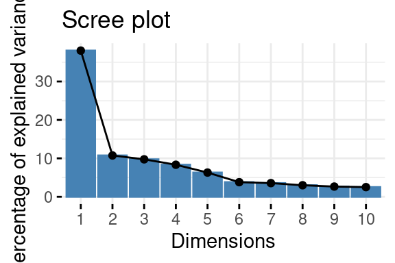

Dimensions 2 and 3 similar order of importance.

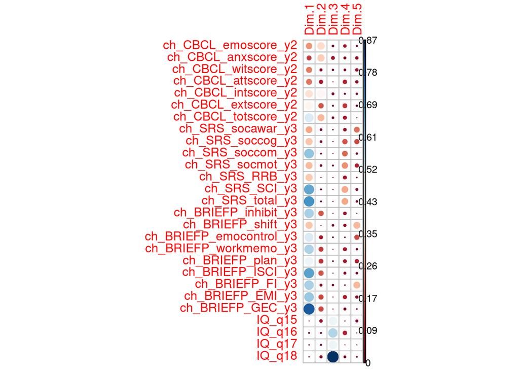

Dimensions 1 and 3 seem a more interesting and more interpretable projection of our space given the problematic as the plan is broadly separated by:

- Dim 1: all scores except IQ
- Dim 3: IQ

Wheras Dim 2 is just another combination of non IQ scores.

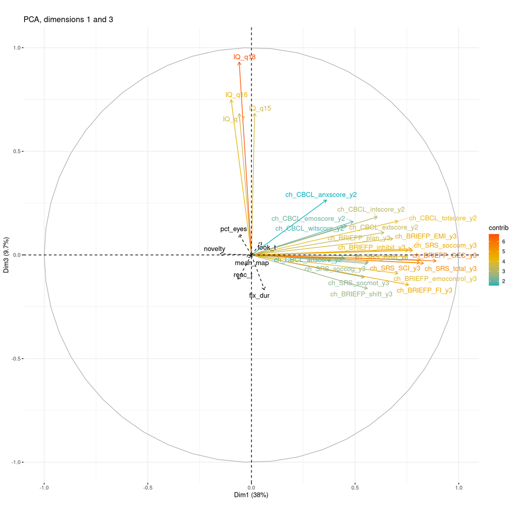

- Reaction to novelty clearly inversely correlated to non IQ scores
  - **Higher attraction to novelty would be associated with lower non IQ scores**
- Reaction time, fixation duration and %eyes seems more associated with IQ (inversely for reaction time and fixation duration)
  - **Shorter reaction time and shorter fixation durations would be associated with higher IQ**
- Reaction time and fixation duration seem less strongly and oppositely associated with non IQ scores
- Harder to see for looking time and mean map, once again, I am not convinced by these two scores

# 5 Correlation between neuro scores and eye tracker scores

## 5.1 CBCL & MCHAT

For the CBCL, **Higher scores indicate greater problems** [link to ref](https://en.wikipedia.org/wiki/Child_Behavior_Checklist).

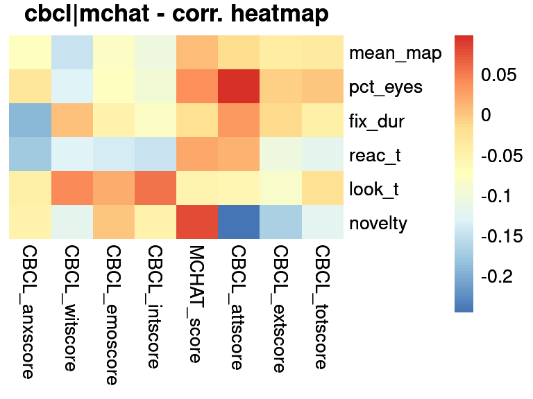

significant correlations:

| outcome | score | n | cor | p |
| --- | --- | --- | --- | --- |
| novelty | CBCL_attscore | 149 | -0.25 | 0.003 |
| fix_dur | CBCL_anxscore | 149 | -0.19 | 0.020 |
| reac_t | CBCL_anxscore | 144 | -0.17 | 0.037 |
| novelty | CBCL_extscore | 149 | -0.17 | 0.043 |

## 5.2 SRS

*A total T-score of 76 or higher is considered severe and strongly associated with clinical diagnosis of Autistic Disorder. T-scores of 66 through 75 are interpreted as indicating Moderate deficiencies in reciprocal social behavior that are clinically significant and lead to substantial interference in everyday social interactions, whereas T-scores of 60 to 65 are in the Mild range and indicate mild to moderate deficits in social interaction. T scores of 59 and below are considered to be within typical limits and generally not associated with clinically significant ASD.* [link to ref](https://bestpracticeautism.blogspot.com/2013/01/test-review-social-responsiveness-scale.html)

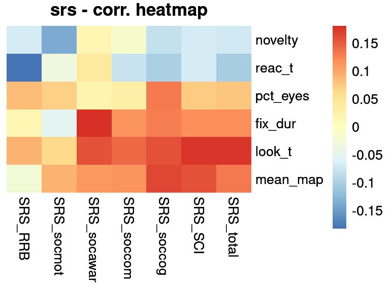

significant correlations:

| outcome | score | n | cor | p |
| --- | --- | --- | --- | --- |
| fix_dur | SRS_socawar | 144 | 0.18 | 0.030 |
| reac_t | SRS_RRB | 139 | -0.18 | 0.031 |
| look_t | SRS_SCI | 144 | 0.18 | 0.035 |
| look_t | SRS_total | 144 | 0.18 | 0.035 |
| mean_map | SRS_soccog | 145 | 0.17 | 0.045 |

## 5.3 BRIEFP

*High scores obtained on the BRIEF do not indicate a “disorder of executive function” but rather suggest a higher level of dysfunction in a specific domain of executive functions.* [link to ref wiki](https://en.wikipedia.org/wiki/Behavior_Rating_Inventory_of_Executive_Function)

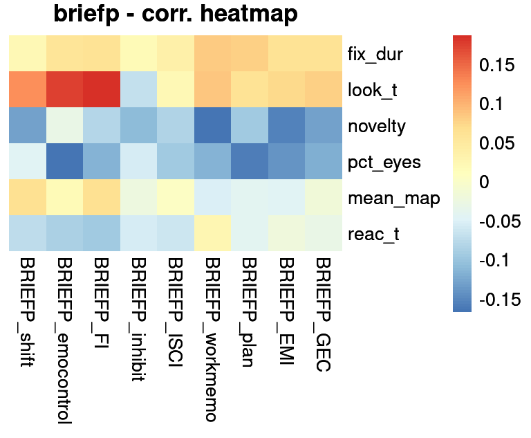

significant correlations:

| outcome | score | n | cor | p |
| --- | --- | --- | --- | --- |
| look_t | BRIEFP_FI | 146 | 0.19 | 0.024 |
| look_t | BRIEFP_emocontrol | 147 | 0.18 | 0.032 |
| pct_eyes | BRIEFP_emocontrol | 147 | -0.17 | 0.043 |
| novelty | BRIEFP_workmemo | 144 | -0.17 | 0.046 |

## 5.4 IQ

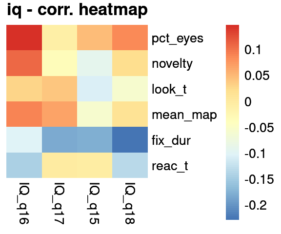

significant correlations:

| outcome | score | n | cor | p |
| --- | --- | --- | --- | --- |
| fix_dur | IQ_q18 | 143 | -0.23 | 0.006 |
| fix_dur | IQ_q17 | 142 | -0.18 | 0.029 |
| fix_dur | IQ_q15 | 143 | -0.18 | 0.034 |

- IQ scores only correlated significantly to **fixation duration**
- **Longer mean fixation duration** seems to be associated with **lower IQ** scores

# 6 Summary

- Regarding eye tracker scores
  - except for (mean map and % eyes) and (fixation duration and looking time) all scores are rather independent
- Regarding neuro scores:
  - CBCL, SRS, BRIEFP are correlated together
  - IQ is independant from the others
- Correlation between neuro and eye tracker
  - Attraction to novel faces negatively associated with non IQ scores
  - Reaction time and Fixation duration negatively associated with IQ
- Consequences
  - Lower reaction to novel faces is “bad” (which we knew) and could be associated with deteriorated non IQ scores
  - Longer reaction times and fixation durations are “bad” (which we kind of suspected due to the plots by age but were but were not sure of) and could be associated with lower IQ